# Q.1 DOMAIN: Botanical research

# Q.4: DOMAIN: Botanical research

## CONTEXT:

University X is currently undergoing some research involving understanding the characteristics of flowers. They already have have invested on curating sample images. They require an automation which can create a classifier capable of determining a flower’s species from a photo

## DATA DESCRIPTION:

The dataset comprises of images from 17 plant species. It can be downloaded from TensorFlow [ Hint: import tflearn.datasets.oxflower17 as oxflower17 ]

## PROJECT OBJECTIVE:

Company’s management requires an automation which can create a classifier capable of determining a flower’s species from a photo

## Steps and tasks: [ Total Score: 25 points]

1. Import the data. Analyse the dimensions of the data.
2. Preprocess the data.
3. Data visualisation:
- Display the images
- Display the labels
- Display images vs labels
- Apply different filters [ for example: blur, contour, edge detection, emboss, smooth etc.] on the images and display the image.List item
1. Train tune and test AIML image classifier model using:
- Use supervised learning algorithms for training
- Use neural networks for training
- Use CNN for training
- Use various CNN with transferred learning models for training
- Compare the results from the above step along with your detailed observations
1. Create a GUI to import the image “Prediction.jpg” and use the above designed AIML image classification model to predict the class/label of this image.

```python
import tensorflow as tf
tf.__version__

import random
random.seed(0)

import warnings
warnings.filterwarnings('ignore')

import matplotlib.pyplot as plt
%matplotlib inline
import numpy as np
from tqdm import tqdm
import pandas as pd
```

```python
device_name = tf.test.gpu_device_name()
if device_name != '/device:GPU:0':
  raise SystemError('GPU device not found')
print('Found GPU at: {}'.format(device_name))
```

```
Found GPU at: /device:GPU:0
```

### 1) Import the data. Analyse the dimensions of the data.

```python
from google.colab import drive
drive.mount('/content/gdrive')
flower_path = '/content/gdrive/MyDrive/Colab/Computer Vision/CNN-Flower-dataset/Flowers - Classification/'  #Destination path where the dataset will be downloaded
```

```python
import os
os.getcwd()
os.chdir(flower_path)
os.getcwd()
```

```
'/content/gdrive/.shortcut-targets-by-id/1OjUMf865whc7y2ZHDvA0gTvAQxMl_P68/Flowers - Classification'
```

```python
# checking dimensions of a test image
from PIL import Image
import cv2
import numpy as np
IMAGE_SIZE = 128  # Target image size for training and evaluation

#actual path is /content/gdrive/MyDrive/Colab/Computer Vision/CNN-Flower-dataset/Flowers - Classification/17flowers- train/jpg/0/image_0001.jpg

test_image_path = flower_path + '17flowers- train/jpg/0/image_0001.jpg'
print(test_image_path)
test_image = cv2.imread(test_image_path)
print('Original size of the test_image: ', test_image.shape)
```

```
/content/gdrive/MyDrive/Colab/Computer Vision/CNN-Flower-dataset/Flowers - Classification/17flowers- train/jpg/0/image_0001.jpg
Original size of the test_image:  (500, 689, 3)
```

### 2) Preprocess the data.

#### Image Data Augmentation for Deep Learning and CNN

```python
from tensorflow.keras.preprocessing.image import ImageDataGenerator
```

```python
datapath = flower_path + '17flowers- train/jpg/'

# Image augmentation
tr_datagen = ImageDataGenerator(
        #rescale=1./255,
        shear_range=0.2, rotation_range=20,
        zoom_range=0.2, width_shift_range=0.2,
        horizontal_flip=True, vertical_flip=True,
        validation_split=0.2)
val_datagen = ImageDataGenerator(validation_split=0.2) #, rescale=1./255)
tr_generator = tr_datagen.flow_from_directory(
        datapath,
        batch_size=32,
        target_size=(IMAGE_SIZE, IMAGE_SIZE),
        class_mode='categorical',
        subset='training')
val_generator = val_datagen.flow_from_directory(
        datapath,
        batch_size=32,
        target_size=(IMAGE_SIZE, IMAGE_SIZE),
        class_mode='categorical',
        subset='validation', shuffle=False)
```

```
Found 1101 images belonging to 17 classes.
Found 274 images belonging to 17 classes.
```

```python
train_count = tr_generator.samples
print('Number of training Batches: ',int(train_count/32))
```

```
Number of training Batches:  34
```

```python
val_count = val_generator.samples
print('Number of validation Batches: ',int(val_count/32))
```

```
Number of validation Batches:  8
```

```python
# Store the data in X_train, y_train variables by iterating over the batches
tr_generator.reset()
X_train, y_train = next(tr_generator)
for i in tqdm(range(int(train_count/32)-1)):
  img, label = next(tr_generator)
  X_train = np.append(X_train, img, axis=0 )
  y_train = np.append(y_train, label, axis=0)
print(X_train.shape, y_train.shape)
```

```
(1088, 128, 128, 3) (1088, 17)
```

```python
# Store the data in X_val, y_val variables by iterating over the batches
val_generator.reset()
X_val, y_val = next(val_generator)
for i in tqdm(range(int(val_count/32)-1)):
  img, label = next(val_generator)
  X_val = np.append(X_val, img, axis=0 )
  y_val = np.append(y_val, label, axis=0)
print(X_val.shape, y_val.shape)
```

```
(256, 128, 128, 3) (256, 17)
```

```python
print(X_train.shape, y_train.shape, X_val.shape, y_val.shape)
```

```
(1088, 128, 128, 3) (1088, 17) (256, 128, 128, 3) (256, 17)
```

```python
flowers_dict = tr_generator.class_indices
print('Available classes: ', flowers_dict)
flowers_dict.values
a = list(flowers_dict.items())
flowers_np = np.array(a)
flowers = flowers_np[:,0]
print('\n After converting the dictionary into simple array: \n', flowers)
print('\n Referencing a class with index: ', flowers[10])
```

```
Available classes:  {'0': 0, '1': 1, '10': 2, '11': 3, '12': 4, '13': 5, '14': 6, '15': 7, '16': 8, '2': 9, '3': 10, '4': 11, '5': 12, '6': 13, '7': 14, '8': 15, '9': 16}

 After converting the dictionary into simple array:
 ['0' '1' '10' '11' '12' '13' '14' '15' '16' '2' '3' '4' '5' '6' '7' '8'
 '9']

 Referencing a class with index:  3
```

```python
print(X_train.shape, y_train.shape, X_val.shape, y_val.shape)
```

```
(1088, 128, 128, 3) (1088, 17) (256, 128, 128, 3) (256, 17)
```

```python
print(y_train[0])
```

```
[0. 0. 0. 0. 0. 0. 1. 0. 0. 0. 0. 0. 0. 0. 0. 0. 0.]
```

#### Prepare data for SVM

```python
# Flatten the images for SVM
X_train_flat = X_train.reshape(X_train.shape[0], IMAGE_SIZE*IMAGE_SIZE*3)
X_train_flat.shape
```

```
(1088, 49152)
```

```python
# Function to convert y variable into categorical labeled data for SVM
def f(x):
    return flowers[x.argmax()]
```

```python
y_train_flat = np.array(list(map(f,y_train)))
y_train_flat[10]
```

```
'4'
```

```python
print(y_train_flat.shape)
print(np.unique(y_train_flat))
```

```
(1088,)
['0' '1' '10' '11' '12' '13' '14' '15' '16' '2' '3' '4' '5' '6' '7' '8'
 '9']
```

```python
#Similarly for Validation Data
X_val_flat = X_val.reshape(X_val.shape[0], IMAGE_SIZE*IMAGE_SIZE*3)
y_val_flat = np.array(list(map(f,y_val)))
print(X_val_flat.shape, y_val_flat.shape)
```

```
(256, 49152) (256,)
```

### 3) Data visualisation:

- Display the images
- Display the labels
- Display images vs labels
- Apply different filters [ for example: blur, contour, edge detection, emboss, smooth etc.] on the images and display the image

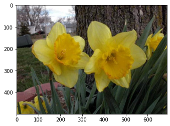

```python
#Visualize one image
plt.subplots(1)
img = Image.open(test_image_path)
plt.imshow(img)
```

[figure not shown]

```python
tr_generator.reset()
image_batch, label_batch = next(tr_generator)
plt.figure(figsize=(10,10))
for i in range(9):
  ax = plt.subplot(3,3, i+1)
  #plt.imshow( image_batch[i].astype('uint8'),cv2.COLOR_BGR2RGB)
  plt.imshow(cv2.cvtColor(image_batch[i].astype('uint8'),cv2.COLOR_BGR2RGB))
  label = label_batch[i].astype('uint8')
  #print(label.argmax())
  plt.title(flowers[label.argmax()])
  #print(label)
  plt.axis('off')
```

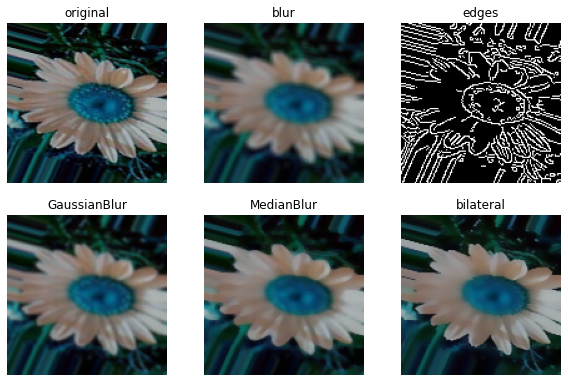

```python
# Apply different filters [ for example: blur, contour, edge detection, emboss, smooth etc.] on the images and display the image

plt.figure(figsize=(10,10))
target_image = image_batch[4]
target_label = label_batch[4]

def plot_img(title, target_image, i):
  ax = plt.subplot(3, 3, i)
  plt.imshow(cv2.cvtColor(target_image.astype('uint8'),cv2.COLOR_BGR2RGB))
  #print(label.argmax())
  plt.title(title)
  #print(label)
  plt.axis('off')

original = target_image
plot_img('original', original, 1)

blur = cv2.blur(target_image, (5,5))
plot_img('blur', blur, 2)

edges = cv2.Canny(target_image.astype('uint8'), 100, 200) # Edge detection
plot_img('edges', edges, 3)

gaussian = cv2.GaussianBlur(target_image, (5,5), 0)
plot_img('GaussianBlur', gaussian, 4)

median = cv2.medianBlur(target_image, 5)
plot_img('MedianBlur', median, 5)

bilateral = cv2.bilateralFilter(target_image, 9, 75, 75)
plot_img('bilateral', bilateral, 6)
```

## 4) Train tune and test AIML image classifier model using:

- Use supervised learning algorithms for training
- Use neural networks for training
- Use CNN for training
- Use various CNN with transferred learning models for training
- Compare the results from the above step along with your detailed observations.

### 1. Supervised Learning: SVM

```python
from sklearn.svm import SVC
svc = SVC()
with tf.device('/device:GPU:0'):
  svc.fit(X_train_flat, y_train_flat)
```

```python
with tf.device('/device:GPU:0'):
  svc_score = svc.score(X_val_flat, y_val_flat)
```

```python
print(svc_score)
```

```
0.3359375
```

```python
y_pred_svc = svc.predict(X_val_flat)
print(classification_report(y_val_flat, y_pred_svc))
```

```
              precision    recall  f1-score   support

           0       0.12      0.12      0.12        16
           1       0.22      0.12      0.16        16
          10       0.41      0.81      0.54        16
          11       0.37      0.41      0.39        17
          12       0.29      0.75      0.42        16
          13       0.20      0.06      0.09        17
          14       0.38      0.19      0.25        16
          15       0.26      0.38      0.31        16
          16       0.56      0.31      0.40        16
           2       0.71      0.31      0.43        16
           3       0.17      0.12      0.14        16
           4       0.20      0.25      0.22        16
           5       0.50      0.62      0.56        16
           6       0.89      0.50      0.64        16
           7       0.12      0.06      0.08        16
           8       0.36      0.36      0.36        14
           9       0.00      0.00      0.00         0

    accuracy                           0.34       256
   macro avg       0.34      0.32      0.30       256
weighted avg       0.36      0.34      0.32       256
```

### 2. Deep Learning

```python
from tensorflow.keras.models import Sequential
from tensorflow.keras.layers import Dense, BatchNormalization, Flatten, Dropout
from tensorflow.keras.optimizers import Adam
from tensorflow.keras.callbacks import Callback, EarlyStopping, ModelCheckpoint
```

```python
# Define the Dense Neural network model
model = Sequential()
model.add(Flatten())
model.add(BatchNormalization())
model.add(Dense(128, input_shape=X_train[0].shape, activation='relu'))
model.add(Dropout(0.4))

model.add(BatchNormalization())
model.add(Dense(64, activation='relu'))
model.add(Dropout(0.4))

model.add(BatchNormalization())
model.add(Dense(32, activation='relu'))
model.add(Dropout(0.4))

model.add(Dense(17, activation='softmax'))
```

```python
# Add Callbacks to pick the best model parameters
earlystop = EarlyStopping(monitor='val_loss', min_delta=0.001, patience=5, restore_best_weights=True)
checkpoint = ModelCheckpoint(filepath ='/tmp/checkpoint', monitor='val_loss', mode='min', save_best_only=True, verbose=1)
```

```python
X_train.shape[1:]
```

```
(128, 128, 3)
```

```python
print(X_train.shape, y_train.shape, X_val.shape, y_val.shape)
```

```
(1088, 128, 128, 3) (1088, 17) (256, 128, 128, 3) (256, 17)
```

```python
adam_opt = Adam(learning_rate=0.001, beta_1=0.9, beta_2=0.999, amsgrad=False)
model.compile(adam_opt, loss='categorical_crossentropy', metrics=['accuracy', tf.keras.metrics.Precision(), tf.keras.metrics.Recall()])
```

```python
device_name = tf.test.gpu_device_name()
if device_name != '/device:GPU:0':
  print(
      '\n\nThis error most likely means that this notebook is not '
      'configured to use a GPU.  Change this in Notebook Settings via the '
      'command palette (cmd/ctrl-shift-P) or the Edit menu.\n\n')
  raise SystemError('GPU device not found')

with tf.device('/device:GPU:0'):
  model.fit(tr_generator, validation_data=val_generator, steps_per_epoch=int(len(X_train)/32), epochs=100, callbacks=[earlystop, checkpoint])
```

```
Epoch 00001: val_loss improved from inf to 8.62729, saving model to /tmp/checkpoint
INFO:tensorflow:Assets written to: /tmp/checkpoint/assets

Epoch 00002: val_loss improved from 8.62729 to 3.47213, saving model to /tmp/checkpoint
INFO:tensorflow:Assets written to: /tmp/checkpoint/assets

Epoch 00003: val_loss improved from 3.47213 to 2.79246, saving model to /tmp/checkpoint
INFO:tensorflow:Assets written to: /tmp/checkpoint/assets

Epoch 00004: val_loss improved from 2.79246 to 2.65623, saving model to /tmp/checkpoint
INFO:tensorflow:Assets written to: /tmp/checkpoint/assets

Epoch 00005: val_loss improved from 2.65623 to 2.51354, saving model to /tmp/checkpoint
INFO:tensorflow:Assets written to: /tmp/checkpoint/assets

Epoch 00006: val_loss improved from 2.51354 to 2.42233, saving model to /tmp/checkpoint
INFO:tensorflow:Assets written to: /tmp/checkpoint/assets

Epoch 00007: val_loss improved from 2.42233 to 2.36176, saving model to /tmp/checkpoint
INFO:tensorflow:Assets written to: /tmp/checkpoint/assets

Epoch 00008: val_loss improved from 2.36176 to 2.31734, saving model to /tmp/checkpoint
INFO:tensorflow:Assets written to: /tmp/checkpoint/assets

Epoch 00009: val_loss improved from 2.31734 to 2.25224, saving model to /tmp/checkpoint
INFO:tensorflow:Assets written to: /tmp/checkpoint/assets

Epoch 00010: val_loss improved from 2.25224 to 2.20173, saving model to /tmp/checkpoint
INFO:tensorflow:Assets written to: /tmp/checkpoint/assets

Epoch 00011: val_loss improved from 2.20173 to 2.18548, saving model to /tmp/checkpoint
INFO:tensorflow:Assets written to: /tmp/checkpoint/assets

Epoch 00012: val_loss improved from 2.18548 to 2.12330, saving model to /tmp/checkpoint
INFO:tensorflow:Assets written to: /tmp/checkpoint/assets

Epoch 00013: val_loss improved from 2.12330 to 2.08385, saving model to /tmp/checkpoint
INFO:tensorflow:Assets written to: /tmp/checkpoint/assets

Epoch 00014: val_loss improved from 2.08385 to 2.04141, saving model to /tmp/checkpoint
```

[output cut: 98 more lines]

```

Epoch 00051: val_loss did not improve from 1.64279

Epoch 00052: val_loss improved from 1.64279 to 1.61927, saving model to /tmp/checkpoint
INFO:tensorflow:Assets written to: /tmp/checkpoint/assets

Epoch 00053: val_loss did not improve from 1.61927

Epoch 00054: val_loss did not improve from 1.61927

Epoch 00055: val_loss did not improve from 1.61927

Epoch 00056: val_loss did not improve from 1.61927

Epoch 00057: val_loss did not improve from 1.61927
```

```python
model.evaluate(X_val, y_val)
```

```
[1.8378034830093384, 0.3125, 0.4583333432674408, 0.04296875]
```

```python
model.evaluate(val_generator)
```

```
[1.6192654371261597,
 0.41605839133262634,
 0.7884615659713745,
 0.14963503181934357]
```

```python
model.summary()
```

```
Model: "sequential"
_________________________________________________________________
Layer (type)                 Output Shape              Param #
=================================================================
flatten (Flatten)            (None, None)              0
_________________________________________________________________
batch_normalization (BatchNo (None, 49152)             196608
_________________________________________________________________
dense (Dense)                (None, 128)               6291584
_________________________________________________________________
dropout (Dropout)            (None, 128)               0
_________________________________________________________________
batch_normalization_1 (Batch (None, 128)               512
_________________________________________________________________
dense_1 (Dense)              (None, 64)                8256
_________________________________________________________________
dropout_1 (Dropout)          (None, 64)                0
_________________________________________________________________
batch_normalization_2 (Batch (None, 64)                256
_________________________________________________________________
dense_2 (Dense)              (None, 32)                2080
_________________________________________________________________
dropout_2 (Dropout)          (None, 32)                0
_________________________________________________________________
dense_3 (Dense)              (None, 17)                561
=================================================================
Total params: 6,499,857
Trainable params: 6,401,169
Non-trainable params: 98,688
_________________________________________________________________
```

### 3. Convolution Neural Networks (CNN)

```python
from tensorflow.keras.layers import Conv2D, MaxPooling2D, Activation
from tensorflow.keras.models import Sequential
from tensorflow.keras.layers import Dense, BatchNormalization, Flatten, Dropout
from tensorflow.keras.optimizers import Adam
from tensorflow.keras.callbacks import Callback, EarlyStopping, ModelCheckpoint
```

```python
conv = Sequential()
conv.add(Conv2D(128, (3,3), padding='same', input_shape=X_train.shape[1:]))
conv.add(BatchNormalization())
conv.add(Activation('relu'))
conv.add(MaxPooling2D(pool_size=(2,2)))
conv.add(Dropout(0.4))

conv.add(Conv2D(64, (3,3), padding='same'))
conv.add(BatchNormalization())
conv.add(Activation('relu'))
conv.add(MaxPooling2D(pool_size=(2,2)))
conv.add(Dropout(0.4))

conv.add(Conv2D(16, (3,3), padding='same'))
conv.add(BatchNormalization())
conv.add(Activation('relu'))
conv.add(Dropout(0.4))

conv.add(Flatten())
conv.add(Dropout(0.4))
conv.add(Dense(17))
conv.add(Activation('softmax'))
```

```python
# Add Callbacks to pick the best model parameters
earlystop = EarlyStopping(monitor='val_loss', min_delta=0.001, patience=5, restore_best_weights=True)
checkpoint = ModelCheckpoint(filepath ='/tmp/checkpoint', monitor='val_loss', mode='min', save_best_only=True, verbose=1)
```

```python
adam_opt = Adam(learning_rate=0.001, beta_1=0.9, beta_2=0.999, amsgrad=True)
conv.compile(adam_opt, loss='categorical_crossentropy', metrics=['accuracy', tf.keras.metrics.Precision(), tf.keras.metrics.Recall()])
```

```python
device_name = tf.test.gpu_device_name()
if device_name != '/device:GPU:0':
  print(
      '\n\nThis error most likely means that this notebook is not '
      'configured to use a GPU.  Change this in Notebook Settings via the '
      'command palette (cmd/ctrl-shift-P) or the Edit menu.\n\n')
  raise SystemError('GPU device not found')

with tf.device('/device:GPU:0'):
  conv.fit(tr_generator, validation_data=val_generator, steps_per_epoch=int(len(X_train)/32), epochs=100, callbacks=[earlystop, checkpoint])
```

```
Epoch 00001: val_loss improved from inf to 9.14484, saving model to /tmp/checkpoint
INFO:tensorflow:Assets written to: /tmp/checkpoint/assets

Epoch 00002: val_loss improved from 9.14484 to 4.94136, saving model to /tmp/checkpoint
INFO:tensorflow:Assets written to: /tmp/checkpoint/assets

Epoch 00003: val_loss improved from 4.94136 to 3.49430, saving model to /tmp/checkpoint
INFO:tensorflow:Assets written to: /tmp/checkpoint/assets

Epoch 00004: val_loss did not improve from 3.49430

Epoch 00005: val_loss improved from 3.49430 to 2.13526, saving model to /tmp/checkpoint
INFO:tensorflow:Assets written to: /tmp/checkpoint/assets

Epoch 00006: val_loss did not improve from 2.13526

Epoch 00007: val_loss improved from 2.13526 to 2.13337, saving model to /tmp/checkpoint
INFO:tensorflow:Assets written to: /tmp/checkpoint/assets

Epoch 00008: val_loss improved from 2.13337 to 1.88021, saving model to /tmp/checkpoint
INFO:tensorflow:Assets written to: /tmp/checkpoint/assets

Epoch 00009: val_loss improved from 1.88021 to 1.68810, saving model to /tmp/checkpoint
INFO:tensorflow:Assets written to: /tmp/checkpoint/assets

Epoch 00010: val_loss did not improve from 1.68810

Epoch 00011: val_loss improved from 1.68810 to 1.48897, saving model to /tmp/checkpoint
INFO:tensorflow:Assets written to: /tmp/checkpoint/assets

Epoch 00012: val_loss did not improve from 1.48897

Epoch 00013: val_loss did not improve from 1.48897

Epoch 00014: val_loss did not improve from 1.48897

Epoch 00015: val_loss did not improve from 1.48897

Epoch 00016: val_loss did not improve from 1.48897
```

```python
conv.evaluate(val_generator)
```

```
[1.48897123336792, 0.529197096824646, 0.6213592290878296, 0.46715328097343445]
```

```python
conv.summary()
```

```
Model: "sequential_1"
_________________________________________________________________
Layer (type)                 Output Shape              Param #
=================================================================
conv2d (Conv2D)              (None, 128, 128, 128)     3584
_________________________________________________________________
batch_normalization_3 (Batch (None, 128, 128, 128)     512
_________________________________________________________________
activation (Activation)      (None, 128, 128, 128)     0
_________________________________________________________________
max_pooling2d (MaxPooling2D) (None, 64, 64, 128)       0
_________________________________________________________________
dropout_3 (Dropout)          (None, 64, 64, 128)       0
_________________________________________________________________
conv2d_1 (Conv2D)            (None, 64, 64, 64)        73792
_________________________________________________________________
batch_normalization_4 (Batch (None, 64, 64, 64)        256
_________________________________________________________________
activation_1 (Activation)    (None, 64, 64, 64)        0
_________________________________________________________________
max_pooling2d_1 (MaxPooling2 (None, 32, 32, 64)        0
_________________________________________________________________
dropout_4 (Dropout)          (None, 32, 32, 64)        0
_________________________________________________________________
conv2d_2 (Conv2D)            (None, 32, 32, 16)        9232
_________________________________________________________________
batch_normalization_5 (Batch (None, 32, 32, 16)        64
_________________________________________________________________
activation_2 (Activation)    (None, 32, 32, 16)        0
_________________________________________________________________
dropout_5 (Dropout)          (None, 32, 32, 16)        0
_________________________________________________________________
flatten_1 (Flatten)          (None, 16384)             0
_________________________________________________________________
dropout_6 (Dropout)          (None, 16384)             0
_________________________________________________________________
dense_4 (Dense)              (None, 17)                278545
_________________________________________________________________
activation_3 (Activation)    (None, 17)                0
=================================================================
Total params: 365,985
Trainable params: 365,569
Non-trainable params: 416
_________________________________________________________________
```

### 4. Transfer Leraning with CNN

#### Function based code

- To evaluate various models, create_model and compile_model functions have been defined

```python
# Working Model
def create_model(base_model):
  cnn = Sequential()
  cnn.add(base_model)
  cnn.add(Flatten())
  cnn.add(Dense(512, activation='relu'))
  cnn.add(BatchNormalization())
  cnn.add(Dense(128, activation='relu'))
  cnn.add(BatchNormalization())
  cnn.add(Dense(17, activation='softmax'))
  cnn.summary()
  return cnn
```

```python
# Testing
def create_model(base_model):
  cnn = Sequential()
  cnn.add(base_model)
  cnn.add(Flatten())
  cnn.add(BatchNormalization())
  cnn.add(Dense(256, activation='relu'))
  cnn.add(BatchNormalization())
  cnn.add(Dense(128, activation='relu'))
  cnn.add(BatchNormalization())
  cnn.add(Dense(17, activation='softmax'))
  cnn.summary()
  return cnn
```

```python
def compile_model(cnn, lr):
  # Add Callbacks to pick the best model parameters
  earlystop = EarlyStopping(monitor='val_loss', min_delta=0.001, patience=5, restore_best_weights=True)
  checkpoint = ModelCheckpoint(filepath ='/tmp/checkpoint', monitor='val_loss', mode='min', save_best_only=True, verbose=1)

  # Define an optimizer and compile the model
  adam_opt = Adam(learning_rate=lr, beta_1=0.9, beta_2=0.999, amsgrad=True)
  cnn.compile(optimizer=adam_opt, loss='categorical_crossentropy', metrics=['accuracy', tf.keras.metrics.Precision(), tf.keras.metrics.Recall()])

  # Check if GPU is enable in Coabl notebook
  device_name = tf.test.gpu_device_name()
  if device_name != '/device:GPU:0':
    print(
        '\n\nThis error most likely means that this notebook is not '
        'configured to use a GPU.  Change this in Notebook Settings via the '
        'command palette (cmd/ctrl-shift-P) or the Edit menu.\n\n')
    raise SystemError('GPU device not found')

  with tf.device('/device:GPU:0'):
    cnn.fit_generator(tr_generator, validation_data=val_generator, steps_per_epoch=int(len(X_train)/32), epochs=100, callbacks=[earlystop, checkpoint])
  #print(cnn.evaluate(val_generator))
  return cnn
```

#### a. Transfer learning with VGG16

```python
# Transfer learning with VGG16
from tensorflow.keras.applications.vgg16 import VGG16
from tensorflow.keras.models import Model

vgg = VGG16(include_top=False, weights='imagenet', input_shape=(IMAGE_SIZE, IMAGE_SIZE, 3), pooling='avg')
vgg.trainable = False
model_vgg = create_model(vgg)
```

```
Downloading data from https://storage.googleapis.com/tensorflow/keras-applications/vgg16/vgg16_weights_tf_dim_ordering_tf_kernels_notop.h5
Model: "sequential_2"
_________________________________________________________________
Layer (type)                 Output Shape              Param #
=================================================================
vgg16 (Functional)           (None, 512)               14714688
_________________________________________________________________
flatten_2 (Flatten)          (None, 512)               0
_________________________________________________________________
batch_normalization_6 (Batch (None, 512)               2048
_________________________________________________________________
dense_5 (Dense)              (None, 256)               131328
_________________________________________________________________
batch_normalization_7 (Batch (None, 256)               1024
_________________________________________________________________
dense_6 (Dense)              (None, 128)               32896
_________________________________________________________________
batch_normalization_8 (Batch (None, 128)               512
_________________________________________________________________
dense_7 (Dense)              (None, 17)                2193
=================================================================
Total params: 14,884,689
Trainable params: 168,209
Non-trainable params: 14,716,480
_________________________________________________________________
```

```python
model_vgg = compile_model(model_vgg, lr=0.01)
model_vgg.evaluate(val_generator)
```

```
Epoch 00001: val_loss improved from inf to 6.26009, saving model to /tmp/checkpoint
INFO:tensorflow:Assets written to: /tmp/checkpoint/assets

Epoch 00002: val_loss improved from 6.26009 to 1.82669, saving model to /tmp/checkpoint
INFO:tensorflow:Assets written to: /tmp/checkpoint/assets

Epoch 00003: val_loss improved from 1.82669 to 1.12131, saving model to /tmp/checkpoint
INFO:tensorflow:Assets written to: /tmp/checkpoint/assets

Epoch 00004: val_loss improved from 1.12131 to 0.94883, saving model to /tmp/checkpoint
INFO:tensorflow:Assets written to: /tmp/checkpoint/assets

Epoch 00005: val_loss improved from 0.94883 to 0.92233, saving model to /tmp/checkpoint
INFO:tensorflow:Assets written to: /tmp/checkpoint/assets

Epoch 00006: val_loss improved from 0.92233 to 0.59444, saving model to /tmp/checkpoint
INFO:tensorflow:Assets written to: /tmp/checkpoint/assets

Epoch 00007: val_loss did not improve from 0.59444

Epoch 00008: val_loss did not improve from 0.59444

Epoch 00009: val_loss did not improve from 0.59444

Epoch 00010: val_loss did not improve from 0.59444

Epoch 00011: val_loss improved from 0.59444 to 0.57275, saving model to /tmp/checkpoint
INFO:tensorflow:Assets written to: /tmp/checkpoint/assets

Epoch 00012: val_loss did not improve from 0.57275

Epoch 00013: val_loss did not improve from 0.57275

Epoch 00014: val_loss did not improve from 0.57275

Epoch 00015: val_loss did not improve from 0.57275

Epoch 00016: val_loss did not improve from 0.57275
```

```
[0.5727501511573792, 0.8394160866737366, 0.853383481502533, 0.8284671306610107]
```

```python
model_vgg.evaluate(val_generator)
```

```
[0.5727501511573792, 0.8394160866737366, 0.853383481502533, 0.8284671306610107]
```

#### b. Tranfer learning with Inception net

```python
from tensorflow.keras.applications.inception_v3 import InceptionV3

inception = InceptionV3(include_top=False, weights='imagenet', input_shape=(IMAGE_SIZE, IMAGE_SIZE, 3), pooling='max')
inception.trainable = False
model_inc = create_model(inception)
```

```
Downloading data from https://storage.googleapis.com/tensorflow/keras-applications/inception_v3/inception_v3_weights_tf_dim_ordering_tf_kernels_notop.h5
Model: "sequential_3"
_________________________________________________________________
Layer (type)                 Output Shape              Param #
=================================================================
inception_v3 (Functional)    (None, 2048)              21802784
_________________________________________________________________
flatten_3 (Flatten)          (None, 2048)              0
_________________________________________________________________
batch_normalization_103 (Bat (None, 2048)              8192
_________________________________________________________________
dense_8 (Dense)              (None, 256)               524544
_________________________________________________________________
batch_normalization_104 (Bat (None, 256)               1024
_________________________________________________________________
dense_9 (Dense)              (None, 128)               32896
_________________________________________________________________
batch_normalization_105 (Bat (None, 128)               512
_________________________________________________________________
dense_10 (Dense)             (None, 17)                2193
=================================================================
Total params: 22,372,145
Trainable params: 564,497
Non-trainable params: 21,807,648
_________________________________________________________________
```

```python
# Compile and fit the model
model_inc = compile_model(model_inc, lr=0.01)
model_inc.evaluate(val_generator)
```

```
Epoch 00001: val_loss improved from inf to 30.34941, saving model to /tmp/checkpoint
INFO:tensorflow:Assets written to: /tmp/checkpoint/assets

Epoch 00002: val_loss improved from 30.34941 to 7.58923, saving model to /tmp/checkpoint
INFO:tensorflow:Assets written to: /tmp/checkpoint/assets

Epoch 00003: val_loss improved from 7.58923 to 4.21844, saving model to /tmp/checkpoint
INFO:tensorflow:Assets written to: /tmp/checkpoint/assets

Epoch 00004: val_loss improved from 4.21844 to 2.59938, saving model to /tmp/checkpoint
INFO:tensorflow:Assets written to: /tmp/checkpoint/assets

Epoch 00005: val_loss improved from 2.59938 to 2.34783, saving model to /tmp/checkpoint
INFO:tensorflow:Assets written to: /tmp/checkpoint/assets

Epoch 00006: val_loss improved from 2.34783 to 2.27141, saving model to /tmp/checkpoint
INFO:tensorflow:Assets written to: /tmp/checkpoint/assets

Epoch 00007: val_loss improved from 2.27141 to 2.11298, saving model to /tmp/checkpoint
INFO:tensorflow:Assets written to: /tmp/checkpoint/assets

Epoch 00008: val_loss did not improve from 2.11298

Epoch 00009: val_loss improved from 2.11298 to 2.08907, saving model to /tmp/checkpoint
INFO:tensorflow:Assets written to: /tmp/checkpoint/assets

Epoch 00010: val_loss improved from 2.08907 to 2.00248, saving model to /tmp/checkpoint
INFO:tensorflow:Assets written to: /tmp/checkpoint/assets

Epoch 00011: val_loss did not improve from 2.00248

Epoch 00012: val_loss did not improve from 2.00248

Epoch 00013: val_loss did not improve from 2.00248

Epoch 00014: val_loss did not improve from 2.00248

Epoch 00015: val_loss did not improve from 2.00248
```

```
[2.0024778842926025,
 0.3540146052837372,
 0.6860465407371521,
 0.21532846987247467]
```

```python
model_inc.evaluate(val_generator)
```

```
[2.0024778842926025,
 0.3540146052837372,
 0.6860465407371521,
 0.21532846987247467]
```

#### c. Tranfer learning with Mobilenet

```python
from tensorflow.keras.applications.mobilenet import MobileNet
mobilenet = MobileNet(include_top=False, weights='imagenet', input_shape=(IMAGE_SIZE, IMAGE_SIZE, 3), pooling='max')
mobilenet.trainable = False
model_mob = create_model(mobilenet)
```

```
Downloading data from https://storage.googleapis.com/tensorflow/keras-applications/mobilenet/mobilenet_1_0_128_tf_no_top.h5
Model: "sequential_4"
_________________________________________________________________
Layer (type)                 Output Shape              Param #
=================================================================
mobilenet_1.00_128 (Function (None, 1024)              3228864
_________________________________________________________________
flatten_4 (Flatten)          (None, 1024)              0
_________________________________________________________________
batch_normalization_106 (Bat (None, 1024)              4096
_________________________________________________________________
dense_11 (Dense)             (None, 256)               262400
_________________________________________________________________
batch_normalization_107 (Bat (None, 256)               1024
_________________________________________________________________
dense_12 (Dense)             (None, 128)               32896
_________________________________________________________________
batch_normalization_108 (Bat (None, 128)               512
_________________________________________________________________
dense_13 (Dense)             (None, 17)                2193
=================================================================
Total params: 3,531,985
Trainable params: 300,305
Non-trainable params: 3,231,680
_________________________________________________________________
```

```python
# Compile and fit the model
model_mob = compile_model(model_mob, lr=0.01)
model_mob.evaluate(val_generator)
```

```
Epoch 00001: val_loss improved from inf to 10.07252, saving model to /tmp/checkpoint
INFO:tensorflow:Assets written to: /tmp/checkpoint/assets

Epoch 00002: val_loss improved from 10.07252 to 4.64903, saving model to /tmp/checkpoint
INFO:tensorflow:Assets written to: /tmp/checkpoint/assets

Epoch 00003: val_loss improved from 4.64903 to 2.67705, saving model to /tmp/checkpoint
INFO:tensorflow:Assets written to: /tmp/checkpoint/assets

Epoch 00004: val_loss improved from 2.67705 to 2.59175, saving model to /tmp/checkpoint
INFO:tensorflow:Assets written to: /tmp/checkpoint/assets

Epoch 00005: val_loss improved from 2.59175 to 2.22612, saving model to /tmp/checkpoint
INFO:tensorflow:Assets written to: /tmp/checkpoint/assets

Epoch 00006: val_loss improved from 2.22612 to 2.11706, saving model to /tmp/checkpoint
INFO:tensorflow:Assets written to: /tmp/checkpoint/assets

Epoch 00007: val_loss improved from 2.11706 to 1.78909, saving model to /tmp/checkpoint
INFO:tensorflow:Assets written to: /tmp/checkpoint/assets

Epoch 00008: val_loss improved from 1.78909 to 1.66843, saving model to /tmp/checkpoint
INFO:tensorflow:Assets written to: /tmp/checkpoint/assets

Epoch 00009: val_loss improved from 1.66843 to 1.63611, saving model to /tmp/checkpoint
INFO:tensorflow:Assets written to: /tmp/checkpoint/assets

Epoch 00010: val_loss did not improve from 1.63611

Epoch 00011: val_loss did not improve from 1.63611

Epoch 00012: val_loss improved from 1.63611 to 1.53342, saving model to /tmp/checkpoint
INFO:tensorflow:Assets written to: /tmp/checkpoint/assets

Epoch 00013: val_loss did not improve from 1.53342

Epoch 00014: val_loss did not improve from 1.53342

Epoch 00015: val_loss did not improve from 1.53342

Epoch 00016: val_loss did not improve from 1.53342

Epoch 00017: val_loss did not improve from 1.53342
```

```
[1.5334223508834839,
 0.6058394312858582,
 0.6960352659225464,
 0.5766423344612122]
```

```python
model_mob.evaluate(val_generator)
```

```
[1.5334223508834839,
 0.6058394312858582,
 0.6960352659225464,
 0.5766423344612122]
```

#### **Picking the best model**

```python
best_flower_model = model_vgg
```

### 5) Create a GUI to import the image “Prediction.jpg” and use the above designed AIML image classification model to predict the class/label of this image.

- *Ensure the prediction image **"Flower Prediction - Expected.jpg"** is in the top level directory*

```python
#@title # CLASSIFIER GUI - Great Learning {run: 'auto'}
print('Select the image from Import_Data drop down and click Predict')
#@markdown Step 1: File Name
Import_Data = 'prediction.jpg' #@param [' ', 'prediction.jpg'] {allow-input: true}

#@markdown ## Image Classifier

#Visualize the prediction image
predict_imgpath = flower_path + '' + 'Flower Prediction - Expected.jpg'
#print(predict_imgpath)

import ipywidgets as widgets
from IPython.display import display

button = widgets.Button(description='Predict')
output = widgets.Output()

def on_button_clicked(b):
  with output:
    plt.subplots(1)
    img = Image.open(predict_imgpath)
    plt.axis('off')
    plt.imshow(img)
    plt.show()

    # Predict the flower class
    img = cv2.imread(predict_imgpath)
    img = cv2.resize(img, (IMAGE_SIZE, IMAGE_SIZE))
    img = np.expand_dims(img, axis=0)
    print(img.shape)
    pred = best_flower_model.predict(img)
    print('Predicted Class: ', flowers[pred.argmax()])

button.on_click(on_button_clicked)
display(button, output)
```

```
Select the image from Import_Data drop down and click Predict
```

**Prediction Code snippet for reference**

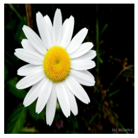

```
(1, 128, 128, 3)
Predicted Class:  10
```

```python
#Visualize the prediction image
predict_imgpath = flower_path + '' + 'Flower Prediction - Expected.jpg'
#print(predict_imgpath)

plt.subplots(1)
img = Image.open(predict_imgpath)
plt.axis('off')
plt.imshow(img)
plt.show()

# Predict the flower class
img = cv2.imread(predict_imgpath)
img = cv2.resize(img, (IMAGE_SIZE, IMAGE_SIZE))
img = np.expand_dims(img, axis=0)
print(img.shape)
pred = best_flower_model.predict(img)
print('Predicted Class: ', flowers[pred.argmax()])
```

```python
print(pred[0].max())
```

```
0.99999535
```

```python
print(pred)
```

```
[[1.2993540e-10 3.8390051e-09 9.9999535e-01 2.5513980e-10 6.4762524e-08
  1.2588734e-13 3.3204339e-11 8.2056495e-08 8.2830666e-11 9.4588859e-12
  3.6301479e-11 1.2661622e-10 4.9820141e-11 4.0418637e-09 1.0570965e-11
  3.9271350e-10 4.5257989e-06]]
```

```python
print('Prediction using VGG Net', flowers[model_vgg.predict(img).argmax()])
print('Prediction using Inception Net', flowers[model_inc.predict(img).argmax()])
print('Prediction using Mobile Net', flowers[model_mob.predict(img).argmax()])
```

```
Prediction using VGG Net 10
Prediction using Inception Net 10
Prediction using Mobile Net 10
```

# Q.5: Explain in depth your strategy to maintain and support the AIML image classifier after it in production.

## Stragegy:

1) Maintain historical data of the model predictions of the image classifier and Quarterly review the model performance trend on the production data

2) Regularly re-run the training with new sets of data and check for improvements in model performance.

3) Keep the training model and production model separate at all times and do not change the production model frequently even if the model performance shows initial fluctuations

4) If the production model performance is observed to be consistently deteriorating and we have new datasets for training, consider updating the production model with the new trained model